# meeting_reports – PalaeOpen

Published

October 22, 2025

Modified

October 26, 2026

# Meeting reports

Here you can find reports from meetings and workshops organised under the PalaeOpen COST Action.

## Completed meetings

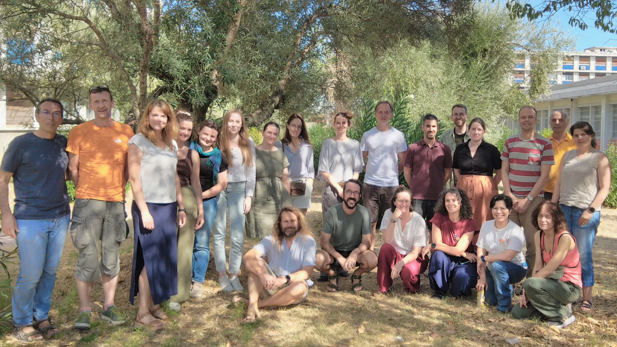

##### Data Stewardship Workshop

How can Data Stewards best ensure high data quality?

October 25, 2026

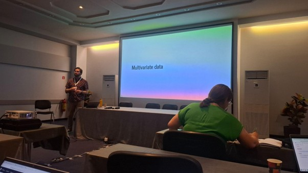

##### Training School on Quantitative Numerical Analyses and Data Stewardship

A five-day training school in Sofia brought together 50 participants from 18 COST Member countries to build practical skills in quantitative analyses and data stewardship for palaeoecological datasets.

July 25, 2026

[figure not shown]

##### How can palaeofire research have the most beneficial impact for fire management policy and practice?

A PalaeOpen workshop brought researchers and practitioners together to identify how long-term fire records can better support fire management and policy.

June 29, 2026

[figure not shown]

##### Archiving and Amalgamation of Chironomid Surface Sediment Datasets

A collaborative initiative to standardise and preserve European chironomid-climate calibration datasets (“Training sets”) for long-term scientific use.

May 21, 2026

[figure not shown]

##### Teacher Training Course and PalaeOpen Workshop – Vilnius, February 2026

On 18–19 February 2026, a two-day teacher training course “Geology and Science Education” was held at Vilnius University, co-organised with Dr. Laura Gedminienė (Nature Research Centre, Lithuania). A dedicated workshop introduced PalaeOpen (CA23116) to secondary school teachers, covering open palaeoecological databases, hands-on microscopy of pollen and diatoms, and practical ways to integrate open scientific data into school curricula.

February 18, 2026

[figure not shown]

##### IAL-IPA PalaeOpen workshop

As part of the IAL-IPA symposium held in Aix-les-Bains (France), a 1-day workshop was held at the Université Savoie Mont Blanc, in Le Bourget-du-Lac. The workshop brought together ca 30 attendees as well as 4 instructors, and participants included both people who had attended previous PalaeOpen activities such as the Chironomid & Diatom workshop in N Macedonia or the Open Science Meeting in the Czech Republic, as well as people completely new to the COST Action. Some people travelled from countries such as Mexico, the US or China, meaning the reach of this workshop extended beyond the typical COST countries.

October 8, 2025

Back to top